# TDR7 Graphiques - Le principe

V. Tolon, V. Payet & J. Martin

28 avril 2021

**Objectifs** : Nous allons découvrir les principes de la production de graphiques qui se comporte trois facettes : la création de graphique avec les différentes options, l’ajout d’éléments supplémentaires et la gestion globale des paramètres graphiques.

[figure not shown]

Nous utilisons ici le jeu de données `t3var` du TD3. Le fichier *t3var.txt* doit être placé dans votre répertoire de travail. C’est un tableau avec 3 variables (poids, tailles et sexes de différentes personnes).

**Exercice :** On importe les données et on stocke les variables dans des objets séparés pour les utiliser plus rapidement :

```r
t3var <- read.table("t3var.txt", header=TRUE, sep="\t",stringsAsFactors = TRUE)
head(t3var)
poi <- t3var$poi
tai <- t3var$tai
sexe <- t3var$sexe
```

# 1 **Créations de graphiques.**

## 1.1 **La fonction de création.**

Plusieurs fonctions permettent de créer des graphiques (voir le TD 8). La plus commune est la fonction `plot()`. Elle produit un graphique très basique.

```
plot(poi~tai)
```

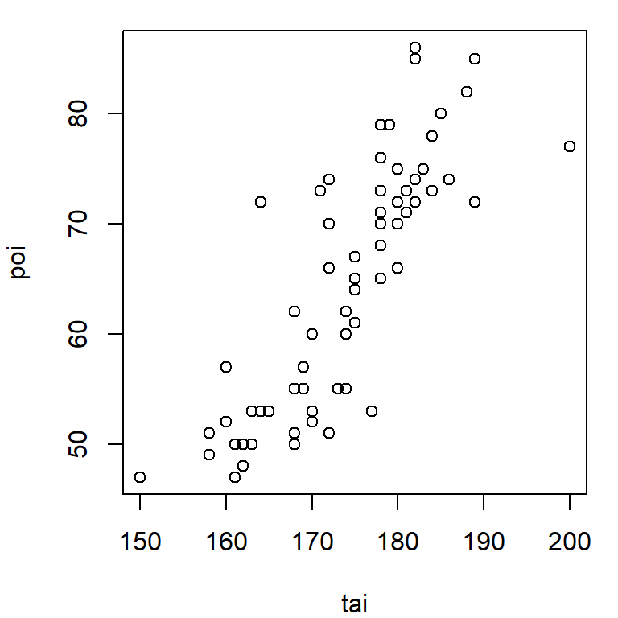

## 1.2 **Les options**

Lors de la création d’un graphique vous pouvez déjà spécifier de nombreuses options. Ici nous préparons de vecteurs de couleurs et de types de points ainsi qu’un titre, puis nous les utilisons dans le graphique. Découvrez les étapes successives :

```r
colo <- c("goldenrod3", "darkblue")[as.numeric(t3var$sexe)]
# des couleurs suivant le sexe
colo[1:10]
##  [1] "darkblue"   "goldenrod3" "goldenrod3" "goldenrod3" "goldenrod3"
##  [6] "goldenrod3" "goldenrod3" "darkblue"   "goldenrod3" "darkblue"
sexe[1:10]
##  [1] h f f f f f f h f h
## Levels: f h
```

```r
pttype <- c(17, 16)[as.numeric(t3var$sexe)]
# des formes de points suivant le sexe
pttype[1:10]
##  [1] 16 17 17 17 17 17 17 16 17 16
```

```r
titre <- paste("Poids et taille de", nrow(t3var), "individus")
# un titre
titre
## [1] "Poids et taille de 66 individus"
```

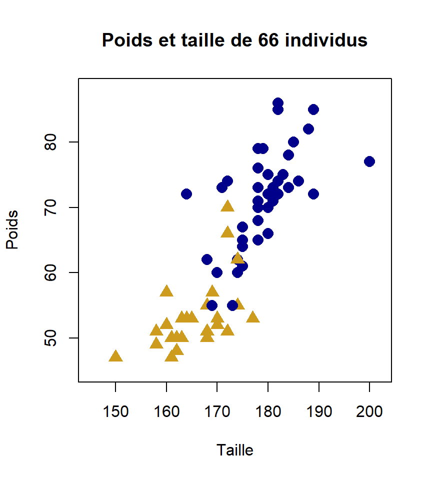

```r
plot(poi~tai,                             # les variables
     main = titre,                        # le titre
     xlab = "Taille", ylab = "Poids",     # les noms des axes
     col = colo, pch = pttype, cex = 1.5, # la couleur, le type et la taille des points
     xlim=c(145,202), ylim=c(45,88))       # limites des axes x et y
```

# 2 **Ajout d’éléments graphiques**

De nombreux éléments peuvent être ajoutés sur un graphique :

- Des points avec `points()`
- Du texte avec `text()`
- Des segments avec `segments()`
- Des flèches avec `arrows()`
- Des droites avec `abline()`
- Des lignes avec `lines()`
- Des rectangles avec `rect()`
- Des légendes avec `legend()`
- Des axes avec `axis()` …

On peut améliorer le graphique précédent.

**Exercice :** Découvrez, testez, modifiez et commentez progressivement le code permettant d’améliorer le graphique :

[figure not shown]

```r
legend(145, 88, c("Femmes", "Hommes"), pch = c(17, 20),
       col = c("goldenrod3", "darkblue"), pt.cex=1.5, cex=0.8)
```

```r
mt <- mean(tai)
mp <- mean(poi)
abline(v=mt, lty=2, lwd=2, col="lightgrey")
abline(h=mp, lty=2, lwd=2, col="lightgrey")
```

```r
arrows(185, 53, 178, 53, angle = 20, le=0.15, col="goldenrod3", lwd=2)
rect(185 ,51, 200, 54, col="goldenrod3", border=NA)
text(185 ,53, "Une femme grande", pos=4, cex=0.6, col="white", font=2)
text(185, 52, "et mince", pos=4, cex=0.6, col="white", font=2)
```

```r
points(mt, mp, cex=2, pch=16)
segments(mt, mp, mt-10, mp+2)
text(mt-10, mp+2, "Moyenne", pos=2, cex=0.7, font=2)
```

# 3 **Paramètres graphiques avec `par()`**

En amont de la création de graphique nous devons réfléchir à la disposition et l’aspect final de notre figure, surtout si nous souhaitons en produire de multiples. Pour gérer cela il existe une fonction très générale `par()` qui permet de fixer une multitude de paramètres graphiques, qui se conserveront pendant toute la session, ou du moins jusqu’à ce qu’on spécifie de nouveaux paramètres. En voici certains assez utiles :

## 3.1 **Graphiques multiples**

Vous pouvez partitionner votre fenêtre graphique en utilisant :

```
par(mfrow=c(2, 2))
# partitionnement en 2 lignes fois 2 colonnes pour 4 graphiques
```

Lors de la production de graphique ils viendront s’ajouter dans un ordre donné que vous devez repérer.

```
plot(tai, poi)
plot(tai)
plot(poi)
plot(poi, tai)
```

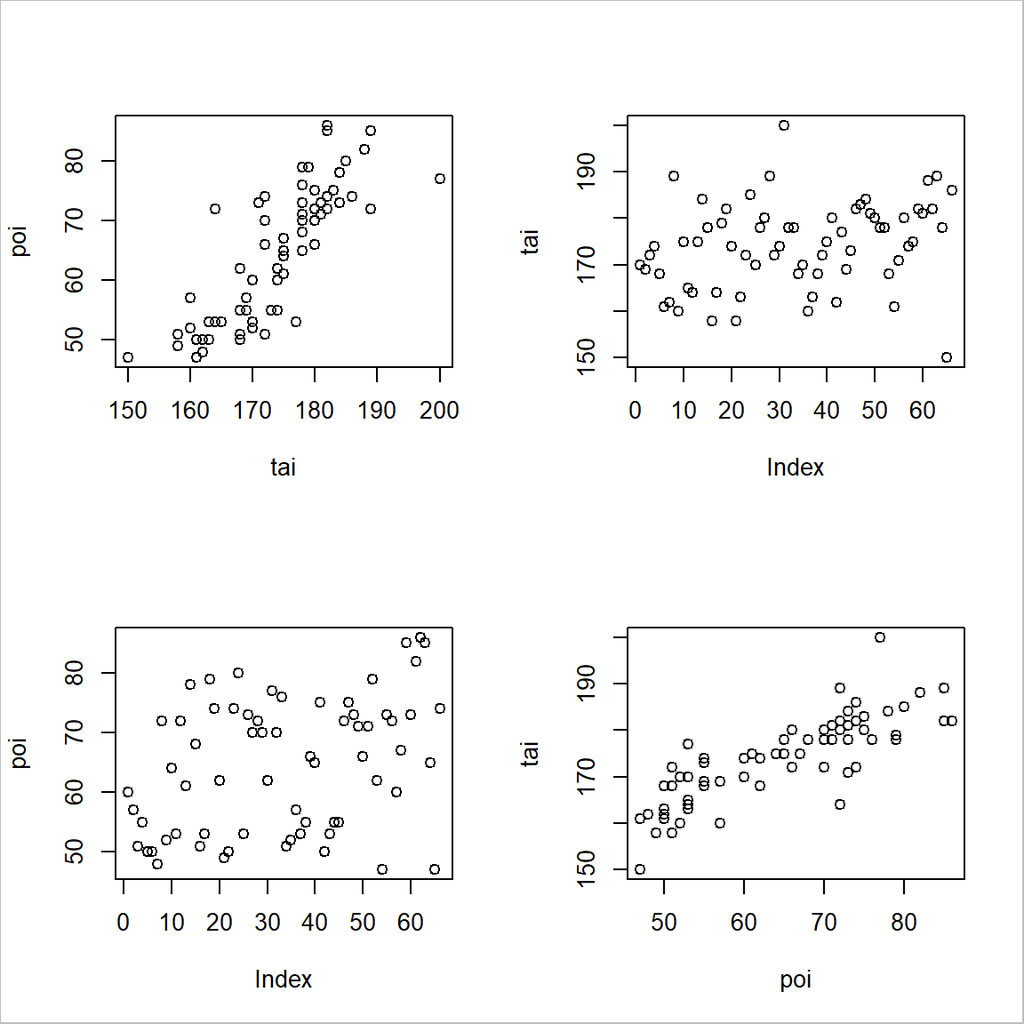

En utilisant `par(mfrow=c(1,2))` vous ferez deux graphique côte à côte, `par(mfrow=c(2,1))` deux graphiques l’un sur l’autre, `par(mfrow=c(3,2))` six graphiques sur trois lignes et deux colonnes… Pour revenir sans partitionnement vous ferez donc `par(mfrow=c(1,1))`.

## 3.2 **Les marges**

Nous pouvons modifier la taille des marges de chaque graphique avec l’option `mar` :

```
par(mfrow=c(2, 2),mar=c(4, 4, 2, 1)) # avec c(bas, gauche, haut, droite)
plot(tai, poi)
plot(tai)
plot(poi)
plot(poi, tai)
```

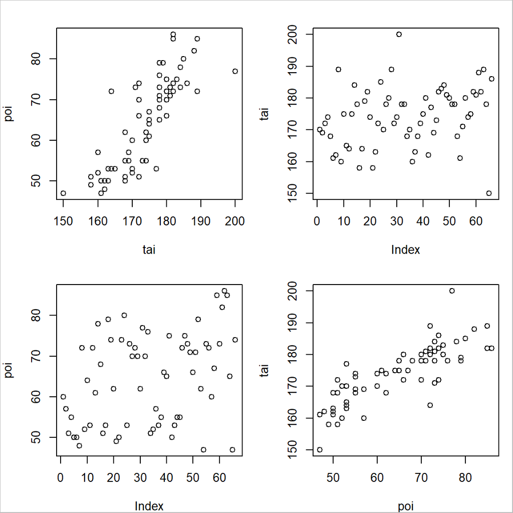

## 3.3 **Autres options**

Il en existe des dizaines, simples ou complexe à mettre en oeuvre. Voici quelques exemples :

- `mgp` : gère la position des titres, des labels et des axes.
- `las` : gère l’orientation des chiffres à coté des axes.
- `tck` : longueur des tirets sur les axes.
- `font.axis`, `font.lab`, `font.main` : police des axes, des titres des axes et du titre du graphique.
- `cex.axis`, `cex.lab`, `cex.main` : taille des axes, des titres des axes et du titre du graphique.
- Regardez la fiche d’aide avec `?par`…

Exemple :

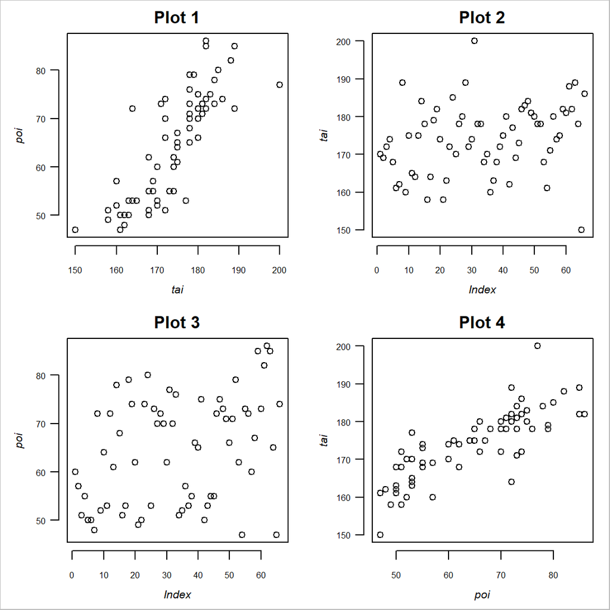

```r
par(mfrow=c(2, 2),mar=c(4, 4, 2, 1),
    mgp=c(2.5, 0.8, 0.5), las=1,  # positions des éléments des axes
    cex.axis=0.6,              # taille des chiffres des axes
    cex.lab=0.8,font.lab=3,    # taille et police des titres des axes
    font.main=2)               # police du titre
plot(tai, poi, main="Plot 1")
plot(tai, main="Plot 2")
plot(poi, main="Plot 3")
plot(poi, tai, main="Plot 4")
```

# 4 **Exercice** (assez difficile…)

**Exercice :** A partir des codes fournis ci-dessus, recréez cette figure à trois graphiques.

**TENTEZ VRAIMENT L’ EXERCICE AVANT D’AFFICHER LE CODE CI-DESSOUS**.

**ATTENTION : les corrections ci-dessous sont données dans le mauvais ordre**.

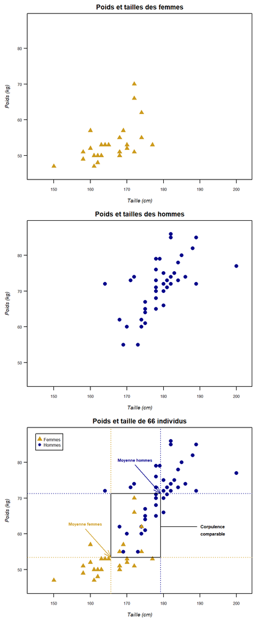

… Avez vous vraiment tenté ?

```r
segments(mth+10, 62, mth, 62, col="black", lwd=1)
text(mth+10, 62, "Corpulence ", pos=4, cex=0.8, col="black", font=2)
text(mth+10, 60, "comparable", pos=4, cex=0.8, col="black", font=2)
```

```r
plot(poi~tai, main = titre, xlab = "Taille (cm)", ylab = "Poids (kg)",
     col = colo, pch = pttype, cex = 1.5,
     xlim=c(145, 202), ylim=c(45, 88))
legend(145, 88, c("Femmes", "Hommes"), pch = c(17, 20),
       col = c("goldenrod3", "darkblue"), pt.cex=1.5, cex=0.8)
```

```r
abline(v=mtf, lty=3, lwd=1, col="goldenrod3")
abline(h=mpf, lty=3, lwd=1, col="goldenrod3")
abline(v=mth, lty=3, lwd=1, col="darkblue")
abline(h=mph, lty=3, lwd=1, col="darkblue")
rect(mtf, mpf, mth, mph,  col=NA, border="black")
```

```r
colo <- c("goldenrod3", "darkblue")[as.numeric(t3var$sexe)]       # des couleurs suivant le sexe
pttype <- c(17, 16)[as.numeric(t3var$sexe)]
```

```r
mtf <- mean(tai[sexe=="f"])
mpf <- mean(poi[sexe=="f"])
mth <- mean(tai[sexe=="h"])
mph <- mean(poi[sexe=="h"])
```

```r
plot(poi[sexe=="f"]~tai[sexe=="f"], main = "Poids et tailles des femmes", xlab = "Taille (cm)", ylab = "Poids (kg)",
     col = "goldenrod3", pch = 17, cex = 1.5,
     xlim=c(145, 202), ylim=c(45, 88))
```

```r
par(mfrow=c(3, 1), mar=c(4, 4, 2, 1),
    mgp=c(2.5, 0.8, 0), las=1,   # positions des éléments des axes
    cex.axis=0.7,               # taille des chiffres des axes
    cex.lab=0.9, font.lab=3,     # taille et police des titres des axes
    font.main=2)               # police du titre
```

```r
arrows(mtf-7, mpf+8, mtf, mpf, col="goldenrod3", angle = 20, le=0.15)
arrows(mth-7, mph+8, mth, mph, col="darkblue", angle = 20, le=0.15)
text(mtf-7, mpf+8, "Moyenne femmes", pos=3, cex=0.7, font=2, col="goldenrod3")
text(mth-7, mph+8, "Moyenne hommes", pos=3, cex=0.7, font=2, col="darkblue")
```

```r
plot(poi[sexe=="h"]~tai[sexe=="h"], main = "Poids et tailles des hommes", xlab = "Taille (cm)", ylab = "Poids (kg)",
     col = "darkblue", pch = 16, cex = 1.5,
     xlim=c(145, 202), ylim=c(45, 88))
```

**Bonne pratique :** Vous venez de tester plusieurs solutions pour créer vos graphiques, choisissez de n’en conserver qu’une seule, ou que certaines, dans votre script et adaptez la suite de votre code à votre choix. Bref nettoyez votre script et rendez le logique.